# Advanced Statistical Inference

Homework #1

# Bronze Tier

Each task is worth 2 points.

## Task 1

Use the attrition data from the rsample package.

```r
library(rsample)
library(dplyr)
library(psych)
library(Hmisc)
library(ggplot2)
library(corrplot)
data("attrition")

summary(attrition)
```

```
##       Age        Attrition            BusinessTravel   DailyRate
##  Min.   :18.00   No :1233   Non-Travel       : 150   Min.   : 102.0
##  1st Qu.:30.00   Yes: 237   Travel_Frequently: 277   1st Qu.: 465.0
##  Median :36.00              Travel_Rarely    :1043   Median : 802.0
##  Mean   :36.92                                       Mean   : 802.5
##  3rd Qu.:43.00                                       3rd Qu.:1157.0
##  Max.   :60.00                                       Max.   :1499.0
##
##                 Department  DistanceFromHome         Education
##  Human_Resources     : 63   Min.   : 1.000   Below_College:170
##  Research_Development:961   1st Qu.: 2.000   College      :282
##  Sales               :446   Median : 7.000   Bachelor     :572
##                             Mean   : 9.193   Master       :398
##                             3rd Qu.:14.000   Doctor       : 48
##                             Max.   :29.000
##
##           EducationField EnvironmentSatisfaction    Gender
##  Human_Resources : 27    Low      :284           Female:588
##  Life_Sciences   :606    Medium   :287           Male  :882
##  Marketing       :159    High     :453
##  Medical         :464    Very_High:446
##  Other           : 82
##  Technical_Degree:132
##
##    HourlyRate       JobInvolvement    JobLevel
##  Min.   : 30.00   Low      : 83    Min.   :1.000
##  1st Qu.: 48.00   Medium   :375    1st Qu.:1.000
##  Median : 66.00   High     :868    Median :2.000
##  Mean   : 65.89   Very_High:144    Mean   :2.064
##  3rd Qu.: 83.75                    3rd Qu.:3.000
##  Max.   :100.00                    Max.   :5.000
##
##                       JobRole     JobSatisfaction  MaritalStatus
##  Sales_Executive          :326   Low      :289    Divorced:327
##  Research_Scientist       :292   Medium   :280    Married :673
##  Laboratory_Technician    :259   High     :442    Single  :470
##  Manufacturing_Director   :145   Very_High:459
##  Healthcare_Representative:131
##  Manager                  :102
##  (Other)                  :215
```

[output cut: 25 more lines]

```
##  Min.   : 0.000   Min.   : 0.000     Min.   : 0.000
##  1st Qu.: 3.000   1st Qu.: 2.000     1st Qu.: 0.000
##  Median : 5.000   Median : 3.000     Median : 1.000
##  Mean   : 7.008   Mean   : 4.229     Mean   : 2.188
##  3rd Qu.: 9.000   3rd Qu.: 7.000     3rd Qu.: 3.000
##  Max.   :40.000   Max.   :18.000     Max.   :15.000
##
##  YearsWithCurrManager
##  Min.   : 0.000
##  1st Qu.: 2.000
##  Median : 3.000
##  Mean   : 4.123
##  3rd Qu.: 7.000
##  Max.   :17.000
##
```

```r
describe(attrition)
```

```
## attrition
##
##  31  Variables      1470  Observations
## ---------------------------------------------------------------------------
## Age
##        n  missing distinct     Info     Mean      Gmd      .05      .10
##     1470        0       43    0.999    36.92    10.33       24       26
##      .25      .50      .75      .90      .95
##       30       36       43       50       54
##
## lowest : 18 19 20 21 22, highest: 56 57 58 59 60
## ---------------------------------------------------------------------------
## Attrition
##        n  missing distinct
##     1470        0        2
##
## Value         No   Yes
## Frequency   1233   237
## Proportion 0.839 0.161
## ---------------------------------------------------------------------------
## BusinessTravel
##        n  missing distinct
##     1470        0        3
##
## Value             Non-Travel Travel_Frequently     Travel_Rarely
## Frequency                150               277              1043
## Proportion             0.102             0.188             0.710
## ---------------------------------------------------------------------------
## DailyRate
##        n  missing distinct     Info     Mean      Gmd      .05      .10
##     1470        0      886        1    802.5      466    165.4    242.8
##      .25      .50      .75      .90      .95
##    465.0    802.0   1157.0   1356.0   1424.1
##
## lowest :  102  103  104  105  106, highest: 1492 1495 1496 1498 1499
## ---------------------------------------------------------------------------
## Department
##        n  missing distinct
##     1470        0        3
##
```

[output cut: 256 more lines]

```
##        n  missing distinct     Info     Mean      Gmd      .05      .10
##     1470        0       18    0.976    4.123    3.904        0        0
##      .25      .50      .75      .90      .95
##        2        3        7        9       10
##
## lowest :  0  1  2  3  4, highest: 13 14 15 16 17
##
## Value          0     1     2     3     4     5     6     7     8     9
## Frequency    263    76   344   142    98    31    29   216   107    64
## Proportion 0.179 0.052 0.234 0.097 0.067 0.021 0.020 0.147 0.073 0.044
##
## Value         10    11    12    13    14    15    16    17
## Frequency     27    22    18    14     5     5     2     7
## Proportion 0.018 0.015 0.012 0.010 0.003 0.003 0.001 0.005
## ---------------------------------------------------------------------------
```

Engage in some data exploration by using `summary` functions.

In addition to the `summary` function, the `describe` functions from the psych and Hmisc packages are great (but for slightly different purposes). Use any function you wish

## Task 2

How do those variables look? Do they appear to all make sense? Are there any extreme values? Are any of them coded in such a way that don’t make sense? Discuss anything interesting that you found.

For the extreme values, I found that the max of YearsAtCompany = 40,but the mean is just 7 and the 90% of people is below 15 years.

Also, for MonthlyIncome, the max =19999,but the median is just 4919

And for the WorkLifeBlance, over 80% choose the good or better.

For education ,doctor just got 0.03.

```r
str(attrition)
```

```
## 'data.frame':    1470 obs. of  31 variables:
##  $ Age                     : int  41 49 37 33 27 32 59 30 38 36 ...
##  $ Attrition               : Factor w/ 2 levels "No","Yes": 2 1 2 1 1 1 1 1 1 1 ...
##  $ BusinessTravel          : Factor w/ 3 levels "Non-Travel","Travel_Frequently",..: 3 2 3 2 3 2 3 3 2 3 ...
##  $ DailyRate               : int  1102 279 1373 1392 591 1005 1324 1358 216 1299 ...
##  $ Department              : Factor w/ 3 levels "Human_Resources",..: 3 2 2 2 2 2 2 2 2 2 ...
##  $ DistanceFromHome        : int  1 8 2 3 2 2 3 24 23 27 ...
##  $ Education               : Ord.factor w/ 5 levels "Below_College"<..: 2 1 2 4 1 2 3 1 3 3 ...
##  $ EducationField          : Factor w/ 6 levels "Human_Resources",..: 2 2 5 2 4 2 4 2 2 4 ...
##  $ EnvironmentSatisfaction : Ord.factor w/ 4 levels "Low"<"Medium"<..: 2 3 4 4 1 4 3 4 4 3 ...
##  $ Gender                  : Factor w/ 2 levels "Female","Male": 1 2 2 1 2 2 1 2 2 2 ...
##  $ HourlyRate              : int  94 61 92 56 40 79 81 67 44 94 ...
##  $ JobInvolvement          : Ord.factor w/ 4 levels "Low"<"Medium"<..: 3 2 2 3 3 3 4 3 2 3 ...
##  $ JobLevel                : int  2 2 1 1 1 1 1 1 3 2 ...
##  $ JobRole                 : Factor w/ 9 levels "Healthcare_Representative",..: 8 7 3 7 3 3 3 3 5 1 ...
```

[output cut: 17 more lines]

Be sure to use the `str` function or the `glimpse` function from dplyr to check the structure of the data.

## Task 3

Pick at least 3 variables for which you want to explore relationships. Given any issues you found in Task 2, convert variables as needed with `as.factor` (forces a variable into a factor – think about a nominal variable), `as.numeric` (forces a variable into a numeric), or anything else that you deem necessary (e.g., create new variables with `mutate`).

WorkLifeBalance Education, YearsAtCompany Monthlyincome

I want to figure out the performance of employees in each education level. So I choose WorkLifeBalance,Education,YearsAtCompany,Monthlyincome to discuss their relationship.

```r
attrition1 <- attrition%>%
  select(WorkLifeBalance,Education,YearsAtCompany,MonthlyIncome)%>%
  mutate(WorkLifeBalance = as.factor(WorkLifeBalance))%>%
  mutate(Education = as.factor(Education))%>%
  mutate(MonthlyIncome = as.numeric(MonthlyIncome))%>%
  mutate(YearsAtCompany = as.numeric(YearsAtCompany))
```

## Task 4

Using the ggplot2 package, create some visualizations. The structure of a ggplot object is as follows: If you want to add some type of grouped function (by color, for instance), you might do something like this:

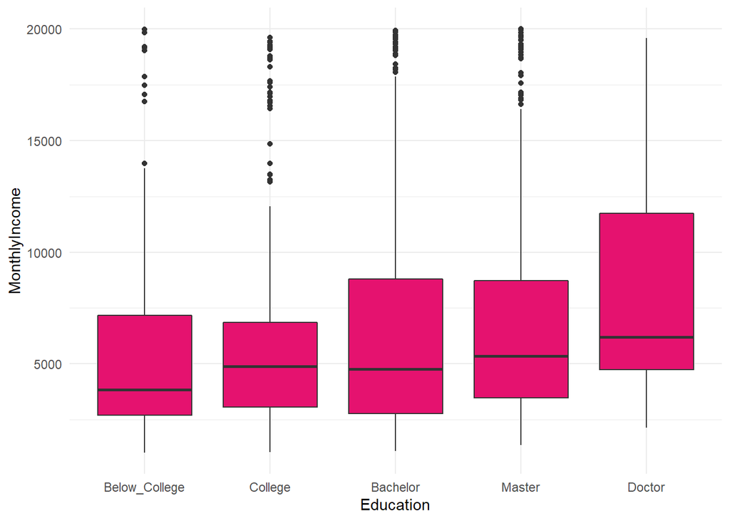

```r
ggplot(attrition1, aes(Education,MonthlyIncome)) +
  geom_boxplot(fill = "#E5126F") +
  theme_minimal()
```

Education~MonthlyIncome: We can find the median of the MonthlyIncome in below_College is the lowest, but has some outliers which is higher than other divisions. At the same time, employees from College,Bachelor and Master almost have the same median.

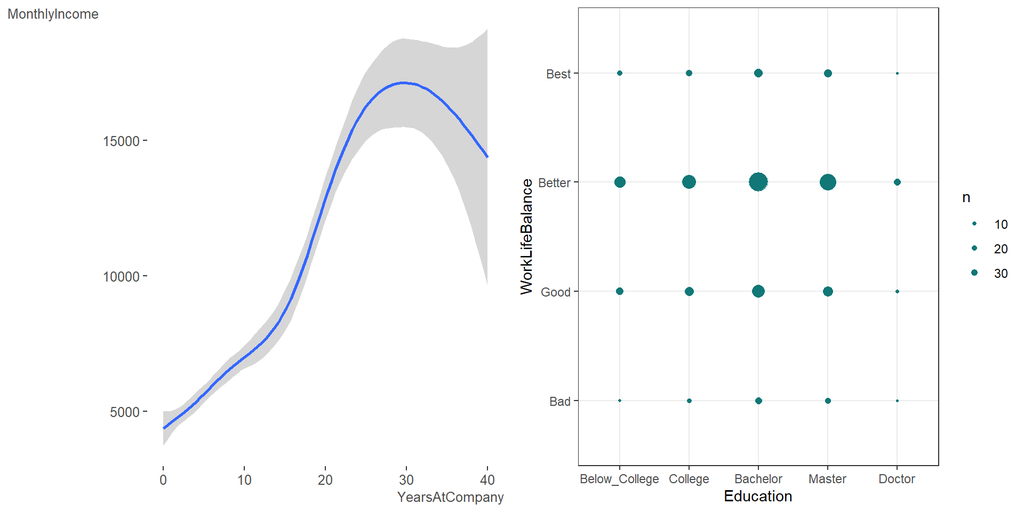

```r
library(Rmisc)
valSize = ggplot(attrition1, aes(YearsAtCompany, MonthlyIncome)) +
  geom_smooth()+
  visibly::theme_trueMinimal()

countSize = ggplot(attrition1, aes(Education,WorkLifeBalance,)) +
  geom_count(color = "#117777") +
  scale_size_area(breaks = c(1, 10, 20, 30)) +
  theme_bw()

multiplot(valSize, countSize, cols = 2)
```

The picture in the left reflects the relationship between YearsAtCompany with MonthlyIncome. We can find employees’Monthlyincome increase with the rise of Yearsatcompany and reach its peak when Yearsatcompany =30 years, then decreased.

The picture in the right reflects the relationship between different levels of Education and Worklifebalance. We can find the largest amount of people is located at the (Bachelor,Better).

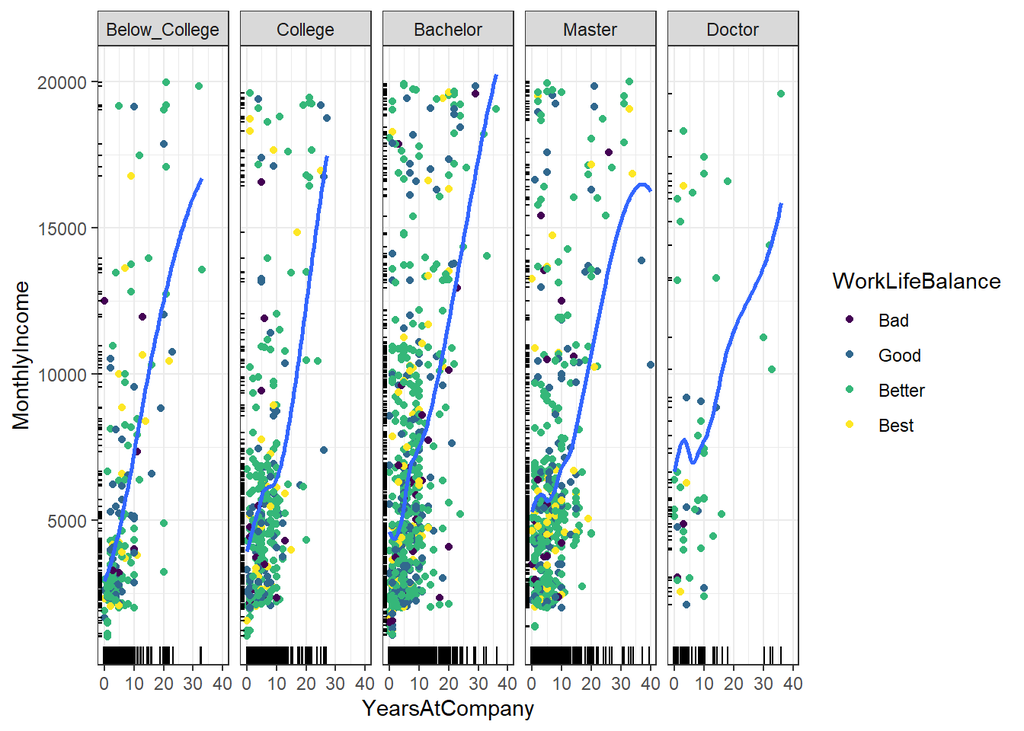

```r
ggplot(attrition1, aes(YearsAtCompany, MonthlyIncome)) +
  geom_point(aes(color = WorkLifeBalance)) +
  geom_rug(position = "jitter") +
  theme_bw() +
  geom_smooth(se = FALSE) +
  facet_grid(. ~ Education)
```

Then I put all the variables together.We can find bachelor has the highest Monthly Income and largest range of Income.Doctor has the least number of bad worklifebalance.For Monthlyincome >15000, majority of people have better worklifebalance.

Once you have produced a visualization, explain what it means. Naturally, good viz doesn’t need explanation, but let’s do it regardless!

## Task 5

Use the `simViz` function from inferviz to see how well you actually do in finding an actual relationship.

### Relationship (Age ~ Totalworkingyears)

[figure not shown]

```r
library(inferviz)

simViz(attrition, Age, TotalWorkingYears, distractors = 7, answer = FALSE)
```

# Reality

First, pick two new variables for relationship exploration – make sure that you have not seen them before.

When you run it the first time, keep the distractors argument at the default value. When asked if you want to see the real data select 1 (No). Now try it with more distractors (maybe 5 or 6).

How did you do? Where you able to spot the real relationship or were you fooled by your basic human need for pattern finding?

Discuss what you think this means.

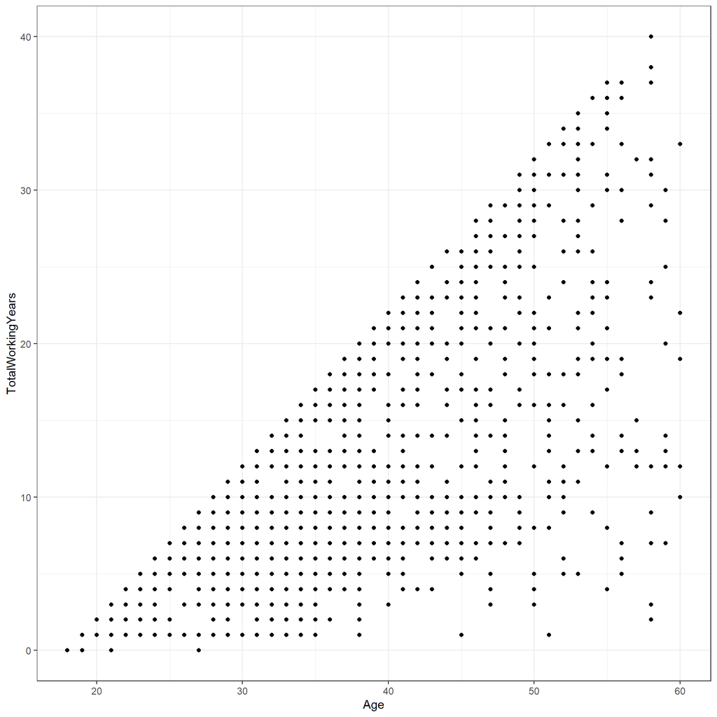

```r
library(ggplot2)

ggplot(attrition,aes( Age, TotalWorkingYears)) +
  geom_point() +
  theme_bw()
```

Inferviz generate ramdom points between the relationship. The more they seems different, the better their relationship. And exactly, the picture 4 are the real relationship between Age and totalworkingyears.

# Silver Tier

For up to 4 points, use the leadershipRatingsAgreement.csv file in the data folder.

You can use any of the following functions to read a csv file into R (from slow to fast):

```r
leadership <- data.table::fread("leadershipRatingsAgreement.csv")
```

```r
summary(leadership)
```

```
##     leaderID        forceful         enabling        strategic
##  Min.   :    2   Min.   :0.0000   Min.   :0.0000   Min.   :0.0000
##  1st Qu.: 3366   1st Qu.:0.1947   1st Qu.:0.1258   1st Qu.:0.1340
##  Median : 7021   Median :0.3346   Median :0.2375   Median :0.2345
##  Mean   : 6840   Mean   :0.4080   Mean   :0.3068   Mean   :0.2988
##  3rd Qu.:10256   3rd Qu.:0.5384   3rd Qu.:0.4056   3rd Qu.:0.3905
##  Max.   :13397   Max.   :2.5085   Max.   :2.2561   Max.   :2.6990
##                  NA's   :265      NA's   :265      NA's   :265
##   operational         vitality         productivity          effect
##  Min.   :0.00000   Min.   :-2.34009   Min.   :-2.25315   Min.   :0.0000
##  1st Qu.:0.06564   1st Qu.:-0.37076   1st Qu.:-0.53558   1st Qu.:0.5774
##  Median :0.11353   Median : 0.12525   Median : 0.08798   Median :0.8539
##  Mean   :0.13540   Mean   :-0.00305   Mean   :-0.00092   Mean   :0.9965
##  3rd Qu.:0.18044   3rd Qu.: 0.39491   3rd Qu.: 0.24458   3rd Qu.:1.2565
##  Max.   :1.12435   Max.   : 1.00665   Max.   : 0.96446   Max.   :4.9329
##  NA's   :265       NA's   :194        NA's   :194
```

```r
str(leadership)
```

```
## Classes 'data.table' and 'data.frame':   4886 obs. of  8 variables:
##  $ leaderID    : int  2 3 6 7 9 10 11 12 14 15 ...
##  $ forceful    : num  0.6538 0.1539 0.0162 0.5637 0.702 ...
##  $ enabling    : num  0.668 0.58 0.234 0.119 0.315 ...
##  $ strategic   : num  0.6637 0.3369 0.1626 0.4747 0.0338 ...
##  $ operational : num  0.2598 0.0981 0.0927 0.1946 0.1502 ...
##  $ vitality    : num  -0.37 0.64 -0.718 0.213 0.129 ...
##  $ productivity: num  -0.04733 0.15063 -0.74538 0.63915 -0.00598 ...
##  $ effect      : num  0.516 0.608 0.854 1.046 1.95 ...
##  - attr(*, ".internal.selfref")=<externalptr>
```

```r
leadership1 <- leadership%>%
  mutate(forceful = ifelse(is.na(forceful), mean(forceful, na.rm = TRUE), forceful)) %>%
  mutate(enabling = ifelse(is.na(enabling), mean(enabling, na.rm = TRUE), enabling)) %>%
  mutate(strategic = ifelse(is.na(strategic), mean(strategic, na.rm = TRUE), strategic)) %>%
  mutate(operational = ifelse(is.na(operational), mean(operational, na.rm = TRUE), operational)) %>%
  mutate(vitality = ifelse(is.na(vitality), mean(vitality, na.rm = TRUE), vitality)) %>%
  mutate(productivity = ifelse(is.na(productivity), mean(productivity, na.rm = TRUE), productivity)) %>%
  mutate(effect = ifelse(is.na(effect), mean(effect, na.rm = TRUE), effect))
```

```r
library(DT); library(broom)

carCor = cor(leadership1[,2:8])

knitr::kable(round(carCor, 2))
```

|  | forceful | enabling | strategic | operational | vitality | productivity | effect |
| --- | --- | --- | --- | --- | --- | --- | --- |
| forceful | 1.00 | 0.59 | 0.49 | 0.58 | -0.15 | -0.08 | 0.33 |
| enabling | 0.59 | 1.00 | 0.50 | 0.43 | -0.17 | -0.07 | 0.39 |
| strategic | 0.49 | 0.50 | 1.00 | 0.45 | -0.14 | -0.11 | 0.34 |
| operational | 0.58 | 0.43 | 0.45 | 1.00 | -0.14 | -0.10 | 0.28 |
| vitality | -0.15 | -0.17 | -0.14 | -0.14 | 1.00 | 0.66 | -0.20 |
| productivity | -0.08 | -0.07 | -0.11 | -0.10 | 0.66 | 1.00 | -0.12 |
| effect | 0.33 | 0.39 | 0.34 | 0.28 | -0.20 | -0.12 | 1.00 |